# Final Project

Evan Ott

December 5, 2016

# Stochastic Gradient Descent (Logistic Regression)

Let’s load in the data and Dr. Scott’s algorithm:

```r
library(ggplot2)
library(latex2exp)
library(Matrix)
library(Rcpp)
library(RcppEigen)
library(reshape2)
Rcpp::sourceCpp("scott_sgdlogit.cpp")
raw_data = read.csv("master_countedByKegg.csv", header = TRUE)
# Read specific columns from the data
gene = as.character(raw_data[ , 1])
data = raw_data[ , 2:ncol(raw_data)]
N = ncol(data)
M = rep(1, N) # Used in logistic regression
# For C++ code, it's easiest to use a sparse matrix
# TODO: might want to consider scaling the counts, either in the way DESeq2 does
# it or something similar.
X = Matrix(as.matrix(unname(data)), sparse = TRUE)
# X[i, j] == data[i, j] is non-negative, so this trims out the genes with no counts
X_nozero = X[which(rowSums(data) > 0), ]
P = nrow(X_nozero)
# Convert the column names to 0 = control, 1 = treatment
Ynames = names(data)
Y = stringi::stri_endswith(Ynames, fixed = "T") * 1
```

Now, let’s create a transformed version of X where the values are on the log scale.

```r
# Copy it as to not damage the original
X_nozero_log = X_nozero
# Oooh I figured out a sweet hack. So the dgCMatrix class could be used in the
# following way:
# X@i are the row indices - 1 (that have ncol sections in non-decreasing order)
# X@p are the indices - 1 in X@i where we switch to a new column
#
# OR
# X@x is the (non-zero) data itself, so why not just edit that? =D
# Here, add a small value because log(1) == 0, and we want to maintain a value there.
# #oneliner
X_nozero_log@x = log2(X_nozero_log@x + 0.1)
```

Now, let’s try to use cross-validation (on the limited number of samples we have) to determine a good range for $\lambda$, the LASSO penalty factor in the stochastic gradient decent logistic regression code.

```r
# Initial guess for the betas.
beta_init = rep(0, P)
# For the weighting in the skip scenario for a feature
# TODO: algorithm is very sensitive to this value
eta = 0.0002
# passes through the data
nIter = 100
# exponentially-weighted moving average factor
# TODO: could explore other values.
discount = 0.01
# X_cv = X_nozero
X_cv = X_nozero_log
folds = 3
col_breaks = cut(1:length(Y), folds, labels = FALSE)
abs_errors = c()
zero_one_errors = c()
lambdas = 10 ^ seq(-1, 4, 0.1)
for (lambda in lambdas) {
  absFoldErrors = c()
  zeroOneFoldErrors = c()
  for (fold in 1:folds) {
    test_ind = which(col_breaks == fold)
    train_ind = which(col_breaks != fold)
    X_nozero_train = X_cv[ , train_ind]
    Y_train = Y[train_ind]
    X_nozero_test = X_cv[ , test_ind]
    Y_test = Y[test_ind]

    train_result = sparsesgd_logit(X_nozero_train, Y_train, M[train_ind], eta, nIter, beta_init, lambda, discount)

    intercept = train_result$alpha
    beta = train_result$beta
    prediction_test = 1/(1 + exp(-(intercept + t(X_nozero_test) %*% beta)))

    # metrics to choose from
    zero_one_error_test = sum(Y_test != round(prediction_test))
    abs_error_test = sum(abs(Y_test - prediction_test))

    absFoldErrors = c(absFoldErrors, abs_error_test)
    zeroOneFoldErrors = c(zeroOneFoldErrors, zero_one_error_test)
  }
  abs_errors = c(abs_errors, mean(absFoldErrors))
  zero_one_errors = c(zero_one_errors, mean(zeroOneFoldErrors))
}
```

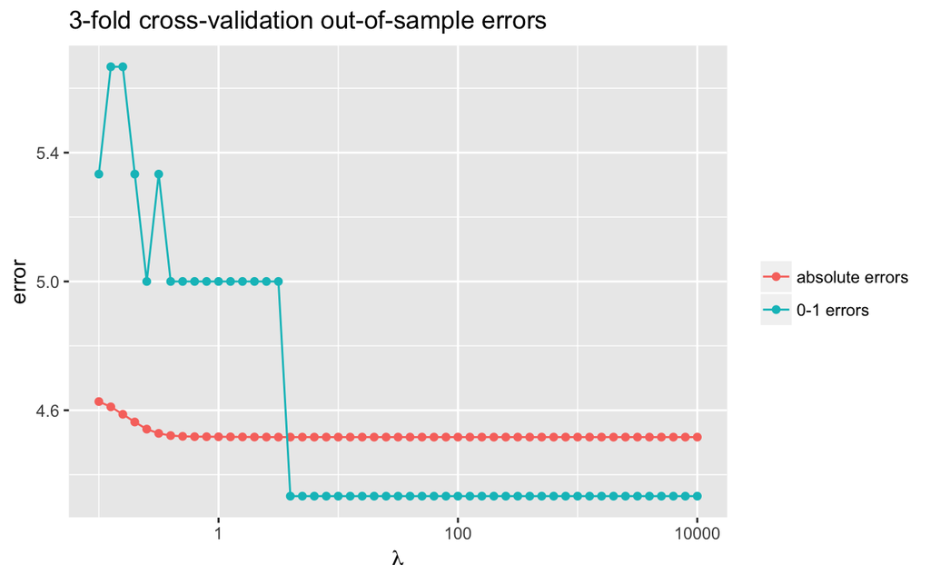

So based on 3-fold cross-validation, the absolute error $\sum_i \left|y_i - \hat{y}_i\right|$ seems to reach its best (minimal) value when $\lambda=10^{-0.4}$ while the 0-1 error $\sum_i \delta\left(y_i,~ \textrm{round}(\hat{y}_i)\right)$ (number of incorrect predictions) exhibits the same behavior around $\lambda=10^{0.6}$.

Let’s take the latter.

```r
ggsave("kegg-cv-prediction.png", g)
```

[output not shown]

[figure not shown]